# Practical Machine Learning Course Project

Lei Fan

2/8/2020

## Overview

As part of this project, we will train a ML model to classify if a wearable user’s barbell lifts are done correctly or incorrectly based on accelerator data.

The original data is available [here](http://groupware.les.inf.puc-rio.br/har).

```r
testing <- read.csv("pml-testing.csv")
training <- read.csv("pml-training.csv")
```

## Cleaning the data

```r
na_columns <- sapply(training, function(col) { mean(is.na(col)) > 0.95 })
train <- training[, !na_columns]
nzv <- nearZeroVar(train)
train <- subset(train, select = -c(nzv))
train <- subset(train, select = -c(user_name, raw_timestamp_part_1, raw_timestamp_part_2, cvtd_timestamp, num_window, X))
```

## Validation set

Given that the test dataset has no output, we need to create a validation data set to get an estimate of our model’s accuracy from the training set.

```r
inTrain <- createDataPartition(train$classe, p = 0.7, list = FALSE)
trainSet <- train[inTrain,]
validateSet <- train[-inTrain,]
```

## Train the model

We will attempt three models: decision tree, random forest, and GBM.

### Decision Tree

We’ll first try training a regular decision tree on the training set, and get the accuracy of the model on the validation set.

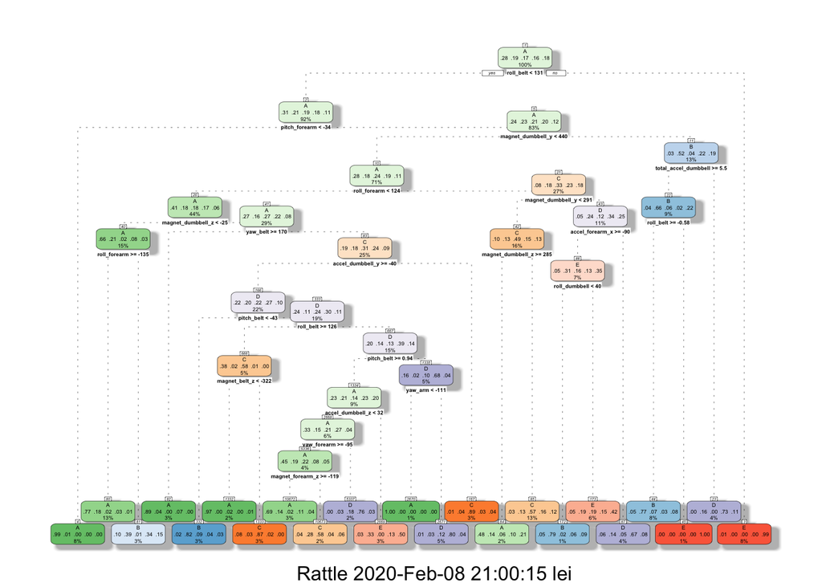

```r
model_rpart <- rpart(classe~., data = trainSet, method = "class")
fancyRpartPlot(model_rpart)
```

```r
confusionMatrix(predict(model_rpart, validateSet, type = "class"), validateSet$classe)
```

```
## Confusion Matrix and Statistics
##
##           Reference
## Prediction    A    B    C    D    E
##          A 1532  176   28   48   41
##          B   54  585   57   64   76
##          C   35  154  819  134  126
##          D   25   76   58  631   56
##          E   28  148   64   87  783
##
## Overall Statistics
##
##                Accuracy : 0.7392
##                  95% CI : (0.7277, 0.7503)
##     No Information Rate : 0.2845
##     P-Value [Acc > NIR] : < 2.2e-16
##
##                   Kappa : 0.6692
##
##  Mcnemar's Test P-Value : < 2.2e-16
##
## Statistics by Class:
##
##                      Class: A Class: B Class: C Class: D Class: E
## Sensitivity            0.9152  0.51361   0.7982   0.6546   0.7237
## Specificity            0.9304  0.94711   0.9076   0.9563   0.9319
## Pos Pred Value         0.8395  0.69976   0.6459   0.7459   0.7054
## Neg Pred Value         0.9650  0.89028   0.9552   0.9339   0.9374
## Prevalence             0.2845  0.19354   0.1743   0.1638   0.1839
## Detection Rate         0.2603  0.09941   0.1392   0.1072   0.1331
## Detection Prevalence   0.3101  0.14206   0.2155   0.1438   0.1886
## Balanced Accuracy      0.9228  0.73036   0.8529   0.8054   0.8278
```

With an accuracy of around 74%, this is not great, but a solid start.

### Random Forest

We’ll then try a random forest model.

```r
model_rf <- train(classe~., data = trainSet, method = "rf", trControl = trainControl(method = "cv", number = 3))
confusionMatrix(predict(model_rf, validateSet), validateSet$classe)
```

```
## Confusion Matrix and Statistics
##
##           Reference
## Prediction    A    B    C    D    E
##          A 1673    4    0    0    0
##          B    1 1134    5    0    0
##          C    0    1 1021   23    0
##          D    0    0    0  940    1
##          E    0    0    0    1 1081
##
## Overall Statistics
##
##                Accuracy : 0.9939
##                  95% CI : (0.9915, 0.9957)
##     No Information Rate : 0.2845
##     P-Value [Acc > NIR] : < 2.2e-16
##
##                   Kappa : 0.9923
##
##  Mcnemar's Test P-Value : NA
##
## Statistics by Class:
##
##                      Class: A Class: B Class: C Class: D Class: E
## Sensitivity            0.9994   0.9956   0.9951   0.9751   0.9991
## Specificity            0.9991   0.9987   0.9951   0.9998   0.9998
## Pos Pred Value         0.9976   0.9947   0.9770   0.9989   0.9991
## Neg Pred Value         0.9998   0.9989   0.9990   0.9951   0.9998
## Prevalence             0.2845   0.1935   0.1743   0.1638   0.1839
## Detection Rate         0.2843   0.1927   0.1735   0.1597   0.1837
## Detection Prevalence   0.2850   0.1937   0.1776   0.1599   0.1839
## Balanced Accuracy      0.9992   0.9972   0.9951   0.9875   0.9994
```

With an accuracy of over 99%, this is a very good model.

### GBM

Lastly we’ll try a GBM.

```r
model_gbm <- train(classe~., data = trainSet, method = "gbm", trControl = trainControl(method = "cv", number = 3))
```

```r
confusionMatrix(predict(model_gbm, validateSet), validateSet$classe)
```

```
## Confusion Matrix and Statistics
##
##           Reference
## Prediction    A    B    C    D    E
##          A 1639   42    0    0    2
##          B   27 1062   36    3   15
##          C    4   30  983   36    4
##          D    4    3    6  920    9
##          E    0    2    1    5 1052
##
## Overall Statistics
##
##                Accuracy : 0.9611
##                  95% CI : (0.9558, 0.9659)
##     No Information Rate : 0.2845
##     P-Value [Acc > NIR] : < 2.2e-16
##
##                   Kappa : 0.9508
##
##  Mcnemar's Test P-Value : 5.904e-07
##
## Statistics by Class:
##
##                      Class: A Class: B Class: C Class: D Class: E
## Sensitivity            0.9791   0.9324   0.9581   0.9544   0.9723
## Specificity            0.9896   0.9829   0.9848   0.9955   0.9983
## Pos Pred Value         0.9739   0.9291   0.9300   0.9766   0.9925
## Neg Pred Value         0.9917   0.9838   0.9911   0.9911   0.9938
## Prevalence             0.2845   0.1935   0.1743   0.1638   0.1839
## Detection Rate         0.2785   0.1805   0.1670   0.1563   0.1788
## Detection Prevalence   0.2860   0.1942   0.1796   0.1601   0.1801
## Balanced Accuracy      0.9843   0.9577   0.9714   0.9749   0.9853
```

The accuracy is only 96%, not as good as the random forest result.

## Predictions on test set

Given that the random forest model has the best result, we will use it to predict the classes of the test set.

```r
predict(model_rf, testing)
```

```
##  [1] B A B A A E D B A A B C B A E E A B B B
## Levels: A B C D E
```

The estimated out-of-sample error should be around 1%.